# 20230110_Temp_RNAseq_NPCs

## Declaring libraries

```r
library("tximport")
library(DESeq2)
library(TxDb.Mmusculus.UCSC.mm10.ensGene)
txdb <- TxDb.Mmusculus.UCSC.mm10.ensGene
library(EnsDb.Mmusculus.v79)
library(kableExtra)
```

## Setting up

Now we need to prepare a transcript database and sample sheet:

```r
k <- keys(txdb, keytype = "TXNAME")
tx2gene <- select(txdb, k, "GENEID", "TXNAME")
samples <- (dir(path = "Kallisto_files_temp/", pattern = "NPC"))
condition <- rep(c("32_degrees", "37_degrees"), times = 4)

sample.sheet <- data.frame(samples,condition, row.names = NULL)
sample.sheet
```

```
##                          samples  condition
## 1 NPC2194_1_32_20230102_Kallisto 32_degrees
## 2 NPC2194_1_37_20230109_Kallisto 37_degrees
## 3 NPC2194_3_32_20230102_Kallisto 32_degrees
## 4 NPC2194_3_37_20230109_Kallisto 37_degrees
## 5 NPC2194_5_32_20230102_Kallisto 32_degrees
## 6 NPC2194_5_37_20230102_Kallisto 37_degrees
## 7 NPC2194_8_32_20230102_Kallisto 32_degrees
## 8 NPC2194_8_37_20230102_Kallisto 37_degrees
```

```r
files <- paste0("Kallisto_files_temp/", samples,"/abundance.h5")
files
```

```
## [1] "Kallisto_files_temp/NPC2194_1_32_20230102_Kallisto/abundance.h5"
## [2] "Kallisto_files_temp/NPC2194_1_37_20230109_Kallisto/abundance.h5"
## [3] "Kallisto_files_temp/NPC2194_3_32_20230102_Kallisto/abundance.h5"
## [4] "Kallisto_files_temp/NPC2194_3_37_20230109_Kallisto/abundance.h5"
## [5] "Kallisto_files_temp/NPC2194_5_32_20230102_Kallisto/abundance.h5"
## [6] "Kallisto_files_temp/NPC2194_5_37_20230102_Kallisto/abundance.h5"
## [7] "Kallisto_files_temp/NPC2194_8_32_20230102_Kallisto/abundance.h5"
## [8] "Kallisto_files_temp/NPC2194_8_37_20230102_Kallisto/abundance.h5"
```

### Removing the NPC_1_37 sample

This sample is not aligning to mouse transcriptome, so we will remove it before analysis:

```r
#Removing the NPC_1_37 sample
files <- files[-2]
files
```

```
## [1] "Kallisto_files_temp/NPC2194_1_32_20230102_Kallisto/abundance.h5"
## [2] "Kallisto_files_temp/NPC2194_3_32_20230102_Kallisto/abundance.h5"
## [3] "Kallisto_files_temp/NPC2194_3_37_20230109_Kallisto/abundance.h5"
## [4] "Kallisto_files_temp/NPC2194_5_32_20230102_Kallisto/abundance.h5"
## [5] "Kallisto_files_temp/NPC2194_5_37_20230102_Kallisto/abundance.h5"
## [6] "Kallisto_files_temp/NPC2194_8_32_20230102_Kallisto/abundance.h5"
## [7] "Kallisto_files_temp/NPC2194_8_37_20230102_Kallisto/abundance.h5"
```

```r
sample.sheet <- sample.sheet[-2,]
sample.sheet
```

```
##                          samples  condition
## 1 NPC2194_1_32_20230102_Kallisto 32_degrees
## 3 NPC2194_3_32_20230102_Kallisto 32_degrees
## 4 NPC2194_3_37_20230109_Kallisto 37_degrees
## 5 NPC2194_5_32_20230102_Kallisto 32_degrees
## 6 NPC2194_5_37_20230102_Kallisto 37_degrees
## 7 NPC2194_8_32_20230102_Kallisto 32_degrees
## 8 NPC2194_8_37_20230102_Kallisto 37_degrees
```

## TXimport

```r
txi <- tximport(files, type = "kallisto", tx2gene = tx2gene,
                ignoreTxVersion = TRUE)
```

```
## 1 2 3 4 5 6 7
## transcripts missing from tx2gene: 58190
## summarizing abundance
## summarizing counts
## summarizing length
## summarizing inferential replicates
```

## DESeq2

```r
ddsTxi <- DESeqDataSetFromTximport(txi,
                                   colData = sample.sheet,
                                   design = ~condition)
```

```
## using counts and average transcript lengths from tximport
```

Only keeping transcripts with at least 10 counts

```r
keep <- rowSums(counts(ddsTxi)) >= 10
dds <- ddsTxi[keep,]
```

Setting “37_degrees” as the reference condition

```r
dds$condition <- relevel(dds$condition, ref = "37_degrees")
```

Performing differential expression analysis

```r
dds <- DESeq(dds)
```

```
## using 'avgTxLength' from assays(dds), correcting for library size
```

```r
res <- results(dds)
res
```

```
## log2 fold change (MLE): condition 32 degrees vs 37 degrees
## Wald test p-value: condition 32 degrees vs 37 degrees
## DataFrame with 18265 rows and 6 columns
##                     baseMean log2FoldChange     lfcSE       stat      pvalue
##                    <numeric>      <numeric> <numeric>  <numeric>   <numeric>
## ENSMUSG00000000001  7894.139      0.0242294 0.0647156   0.374398 7.08109e-01
## ENSMUSG00000000028  1643.748      0.1784724 0.0729345   2.447024 1.44041e-02
## ENSMUSG00000000031    47.423      0.3466995 0.3053004   1.135601 2.56123e-01
## ENSMUSG00000000037   323.281      0.0460340 0.1601399   0.287461 7.73759e-01
## ENSMUSG00000000056   861.151     -0.5554079 0.1230888  -4.512254 6.41422e-06
## ...                      ...            ...       ...        ...         ...
## ENSMUSG00000099146   9.51200       0.610545  0.689928  0.8849395 0.376189279
## ENSMUSG00000099170   5.63797       2.133198  0.987325  2.1605823 0.030727618
## ENSMUSG00000099181   1.86755       0.108043  1.715098  0.0629955 0.949770061
## ENSMUSG00000099216  17.90385      -0.169259  0.494903 -0.3420044 0.732347597
## ENSMUSG00000099250  50.83371      -2.016993  0.612386 -3.2936632 0.000988909
##                           padj
##                      <numeric>
## ENSMUSG00000000001 8.27221e-01
## ENSMUSG00000000028 4.57228e-02
## ENSMUSG00000000031 4.29298e-01
## ENSMUSG00000000037 8.69751e-01
## ENSMUSG00000000056 5.45598e-05
## ...                        ...
## ENSMUSG00000099146  0.55873222
## ENSMUSG00000099170  0.08584029
## ENSMUSG00000099181          NA
## ENSMUSG00000099216  0.84343462
## ENSMUSG00000099250  0.00467044
```

```r
summary(res)
```

```
##
## out of 18265 with nonzero total read count
## adjusted p-value < 0.1
## LFC > 0 (up)       : 2896, 16%
## LFC < 0 (down)     : 3137, 17%
## outliers [1]       : 21, 0.11%
## low counts [2]     : 2125, 12%
## (mean count < 4)
## [1] see 'cooksCutoff' argument of ?results
## [2] see 'independentFiltering' argument of ?results
```

```r
ddscount <- counts(dds, normalized=TRUE)
colnames(ddscount) <- dds$condition

ddscount <- ddscount[,c(3,5,7,1,2,4,6)]
```

Giving us the number of DEGs (p-adj < 0.1)

```r
sum(res$padj < 0.1, na.rm=TRUE)
```

```
## [1] 6033
```

## MA plot

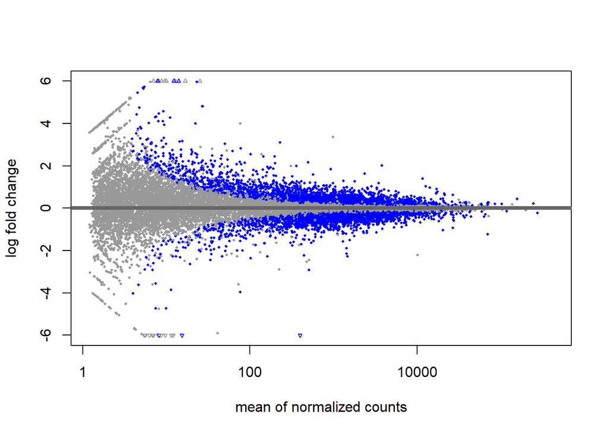

```r
plotMA(res, ylim = c(-6,6), lwd = 1)
```

## Making a histogram of P-values

This is essential for checking if the test is suitable for your data. This [page](http://varianceexplained.org/statistics/interpreting-pvalue-histogram/) gives a good explanation.

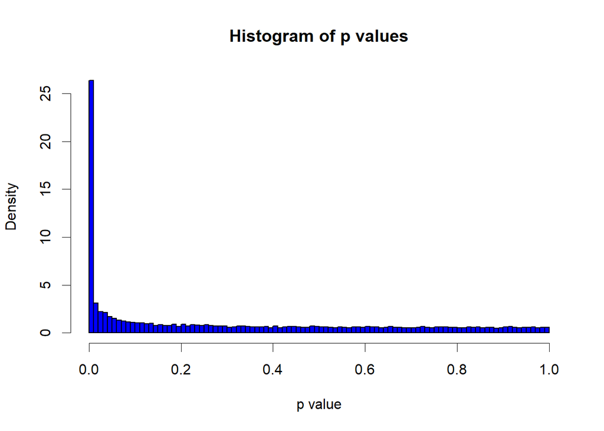

```r
hist(res$pvalue, breaks = 100, main = "Histogram of p values", xlab = "p value", lwd=0.3,freq = FALSE,col="blue")
```

## Checking for experiment quality

### Heatmap of sample-to-sample distances

First, we need to perform Variance stabilizing transformation (vsd) and Regularized log transformation (rld)

```r
vsd <- vst(dds, blind=FALSE)
rld <- rlog(dds, blind=FALSE)
head(assay(vsd), 3)
```

```
##                            1         2         3         4         5         6
## ENSMUSG00000000001 13.074342 13.259938 13.090804 13.117309 13.116658 13.054824
## ENSMUSG00000000028 11.410987 11.398202 11.210329 11.382623 11.331691 11.327583
## ENSMUSG00000000031  9.475488  9.495565  9.372405  9.449691  9.408759  9.470034
##                            7
## ENSMUSG00000000001 13.113122
## ENSMUSG00000000028 11.237880
## ENSMUSG00000000031  9.472047
```

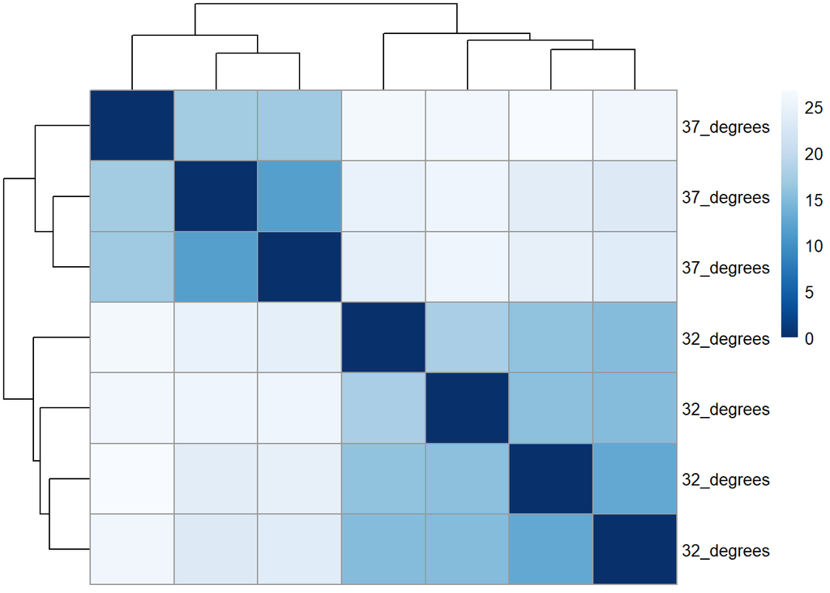

```r
sampleDists <- dist(t(assay(vsd)))
library("RColorBrewer")
library("pheatmap")
sampleDistMatrix <- as.matrix(sampleDists)
rownames(sampleDistMatrix) <- paste(vsd$condition)
colnames(sampleDistMatrix) <- NULL
colors <- colorRampPalette( rev(brewer.pal(9, "Blues")) )(255)
pheatmap(sampleDistMatrix,
         clustering_distance_rows=sampleDists,
         clustering_distance_cols=sampleDists,
         col=colors)
```

### PCA plot of the samples

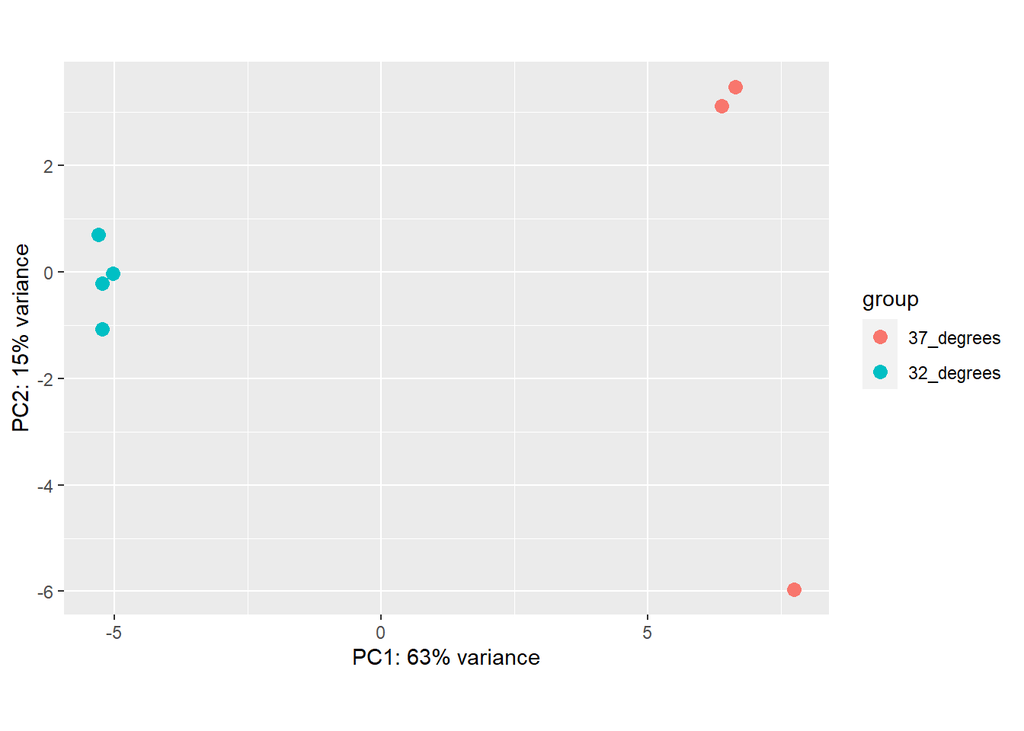

```r
plotPCA(vsd, intgroup=c("condition"))
```

## Getting list of DEGs

Exporting the DEGs, ordered by p-value:

```r
library(dplyr)
#Getting gene symbols
geneIDs1 <- ensembldb::select(EnsDb.Mmusculus.v79, keys= rownames(res), keytype = "GENEID", columns = c("SYMBOL","GENEID"))
res$gene <- geneIDs1$SYMBOL[base::match(rownames(res), geneIDs1$GENEID)]

resOrdered <- res[base::order(res$pvalue),]
resOrdered_with_norm_counts <- merge(as.data.frame(resOrdered), ddscount, by = 'row.names', all =TRUE)
resOrdered_with_norm_counts <- resOrdered_with_norm_counts[order(resOrdered_with_norm_counts$pvalue),]
resOrdered_with_norm_counts <- resOrdered_with_norm_counts[resOrdered_with_norm_counts$padj < 0.1,]
resOrdered_with_norm_counts <- na.omit(resOrdered_with_norm_counts)

all_detected_genes <- na.omit(merge(as.data.frame(resOrdered), ddscount, by = 'row.names', all =TRUE))
all_detected_genes <- all_detected_genes[order(all_detected_genes$padj),]

resForTable <- resOrdered_with_norm_counts[1:20,c(8,2,3,6,7)]
resForTable %>% dplyr::mutate_if(is.numeric, funs(as.character(signif(., 3)))) %>%
    knitr::kable(.,format="pipe", padding=2)
```

|  | gene | baseMean | log2FoldChange | pvalue | padj |
| --- | --- | --- | --- | --- | --- |
| 11260 | Cirbp | 3820 | 2.02 | 4.31e-145 | 6.94e-141 |
| 2226 | Xbp1 | 1430 | -1.88 | 4.13e-140 | 3.33e-136 |
| 1414 | Hspa8 | 70200 | -1.23 | 4.97e-92 | 2.67e-88 |
| 592 | Dnaja3 | 1750 | -1.05 | 9.85e-75 | 3.97e-71 |
| 6470 | Tra2a | 1440 | -2.16 | 2.9e-68 | 9.34e-65 |
| 2576 | Srsf5 | 12700 | 1.02 | 8.47e-66 | 2.28e-62 |
| 10794 | Arrdc4 | 932 | 1.84 | 1.2e-64 | 2.76e-61 |
| 9295 | Iars | 5320 | -0.92 | 2.34e-63 | 4.72e-60 |
| 263 | Chordc1 | 1300 | -1.57 | 6.11e-63 | 1.09e-59 |
| 10181 | Rprd1a | 1620 | -0.977 | 1.61e-61 | 2.6e-58 |
| 7018 | Rbm3 | 17200 | 0.912 | 2.1e-59 | 3.08e-56 |
| 13057 | Cebpg | 1410 | -1.21 | 4.33e-58 | 5.82e-55 |
| 2173 | Kremen1 | 2850 | 1.02 | 4.36e-57 | 5.41e-54 |
| 12496 | Ezr | 3570 | 0.803 | 9.14e-57 | 1.05e-53 |
| 2309 | Rrm2 | 16900 | 0.68 | 1.03e-54 | 1.1e-51 |
| 13630 | Zbtb40 | 542 | -1.64 | 3.06e-54 | 3.08e-51 |
| 4987 | Hspa5 | 20400 | -1.04 | 1.14e-53 | 1.08e-50 |
| 6976 | Rbm10 | 2660 | -0.905 | 3.68e-53 | 3.29e-50 |
| 9412 | Pde4dip | 1320 | -1.17 | 1.77e-50 | 1.5e-47 |
| 13785 | Cttnbp2nl | 2410 | -0.763 | 4.71e-49 | 3.63e-46 |

```r
#knitr::kable(resOrdered_with_norm_counts[1:20,c(8,2,3,6,7)], format="pipe", padding=2, digits = 6)


write.csv(resOrdered_with_norm_counts,
          file="mouse_NPC_temp_DESeq.csv", row.names = FALSE)
```

## Plotting genes

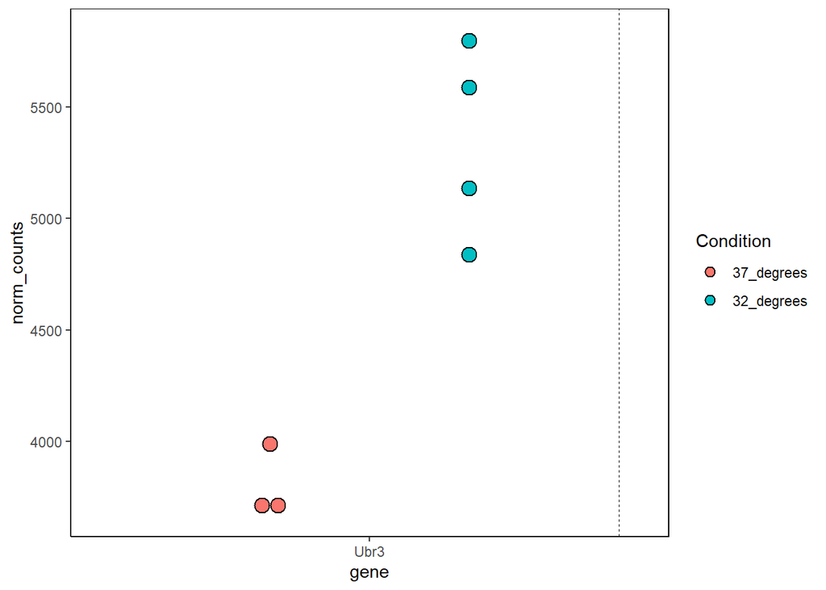

```r
library(ggplot2)
Sp1_Cirbp_Rbm3 <- all_detected_genes[all_detected_genes$gene == "Sp1" | all_detected_genes$gene == "Cirbp" | all_detected_genes$gene == "Rbm3",]
Sp1_Cirbp_Rbm3 <- na.omit(Sp1_Cirbp_Rbm3)
Sp1_Cirbp_Rbm3 <- Sp1_Cirbp_Rbm3[,8:15]

Actb_data <- na.omit(all_detected_genes[all_detected_genes$gene == "Actb"
                                                 | all_detected_genes$gene == "Gapdh"
                                                 | all_detected_genes$gene == "Vcl"
                                                 | all_detected_genes$gene == "Lmnb1",])
Actb_data <- Actb_data[,8:15]


library(tidyr)
library(dplyr)
Sp1_Cirbp_Rbm3_df <- gather(Sp1_Cirbp_Rbm3, key =  "Condition", value = "norm_counts", -gene)
Sp1_Cirbp_Rbm3_df$Condition <- gsub("\\..*","",Sp1_Cirbp_Rbm3_df$Condition)
Sp1_Cirbp_Rbm3_df$Condition <- factor(Sp1_Cirbp_Rbm3_df$Condition,levels = c("37_degrees", "32_degrees"))

Actb_df <- gather(Actb_data, key = "Condition", value = "norm_counts", -gene)
Actb_df$Condition <- gsub("\\..*","",Actb_df$Condition)
Actb_df$Condition <- factor(Actb_df$Condition,levels = c("37_degrees", "32_degrees"))

Ubr3_data <- na.omit(resOrdered_with_norm_counts[resOrdered_with_norm_counts$gene == "Ubr3",])
Ubr3_data <- Ubr3_data[,8:15]
Ubr3_df <- gather(Ubr3_data, key = "Condition", value = "norm_counts", -gene)
Ubr3_df$Condition <- gsub("\\..*","",Ubr3_df$Condition)
Ubr3_df$Condition <- factor(Ubr3_df$Condition,levels = c("37_degrees", "32_degrees"))
ggplot(Ubr3_df,  aes(x = gene, y = norm_counts, fill = Condition)) +  # ggplot function
     #geom_boxplot(position=position_dodge(0.8), lwd = 0.2) +
     geom_dotplot(binaxis = "y", dotsize = 1, stackdir='center', position=position_dodge(0.8))+
     theme_classic() +
      theme(panel.border = element_rect(colour = "black", fill=NA, size=0.5)) +
      geom_vline(xintercept=c(1.5,2.5), linetype="dashed", size = 0.2)
```

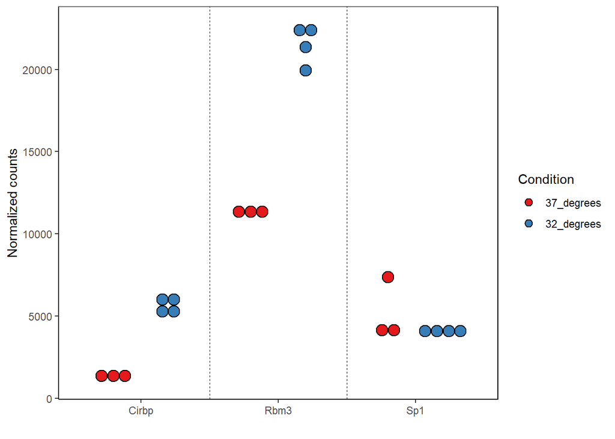

```r
p <- ggplot(Sp1_Cirbp_Rbm3_df, aes(x = gene, y = norm_counts, fill = Condition)) +  # ggplot function
     #geom_boxplot(position=position_dodge(0.8), lwd = 0.2) +
     geom_dotplot(binaxis = "y", dotsize = 1, stackdir='center', position=position_dodge(0.8))+
     theme_classic() +
      theme(panel.border = element_rect(colour = "black", fill=NA, size=0.5)) +
      geom_vline(xintercept=c(1.5,2.5), linetype="dashed", size = 0.2)
p2 <- p+scale_fill_brewer(palette="Set1") + ylab("Normalized counts") + xlab(" ")
p2
```

```r
pdf(file = "Gene_expression_Cirbp_Sp1_Rbm3_NPC_temp.pdf", height = 2.2, width = 3.5, pointsize = 8)
p2
dev.off()
```

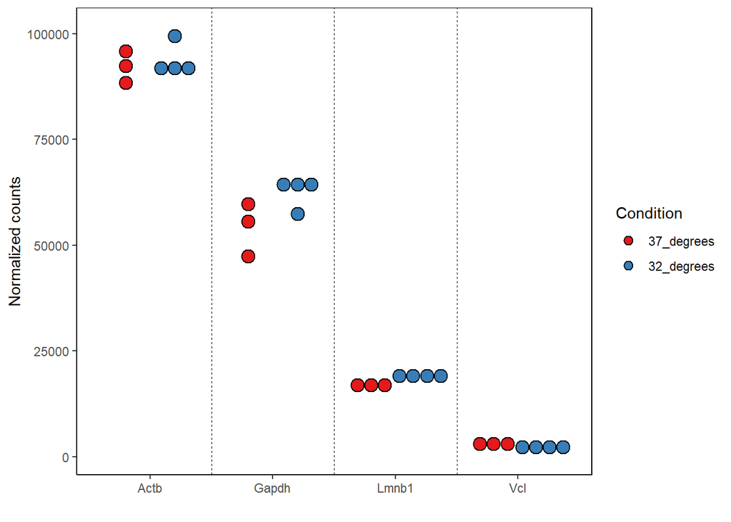

```r
p3 <- ggplot(Actb_df, aes(x = gene, y = norm_counts, fill = Condition)) +  # ggplot function
     #geom_boxplot(position=position_dodge(0.8), lwd = 0.2) +
     geom_dotplot(binaxis = "y", dotsize = 1, stackdir='center', position=position_dodge(0.8))+
     theme_classic() +
      theme(panel.border = element_rect(colour = "black", fill=NA, size=0.5)) +
      geom_vline(xintercept=c(1.5,2.5,3.5), linetype="dashed", size = 0.2)
p4 <- p3 +scale_fill_brewer(palette="Set1") + ylab("Normalized counts") + xlab(" ")
p4
```

## Overlapping with Gecko screen data from Salvör

```r
SP1_repressors <- read.csv("SP1_repressor_list.csv")
RBM3_repressors <- read.csv("RBM3_repressor_list.csv")
SP1_activators <- read.csv("SP1_activator_list.csv")

library(GeneOverlap)

#Capitalising mouse gene symbols so they match with human

Uppercase_temp_DEGs <- toupper(resOrdered_with_norm_counts$gene)
RNAseq_sig_DEGs <- resOrdered_with_norm_counts
RNAseq_sig_DEGs$Uppercase.gene <- Uppercase_temp_DEGs


olap <- function(gecko_list, DEGs){
    olap1 <- newGeneOverlap(gecko_list$Gene.Symbol,DEGs$Uppercase.gene, spec =c("mm9.gene"))
    olap1 <- testGeneOverlap(olap1)
    print(olap1)

    overlapping_genes <- gecko_list[gecko_list$Gene.Symbol %in% DEGs$Uppercase.gene,]
    overlapping_genes$RNAseq_adj_pval <- DEGs$padj[base::match(overlapping_genes$Gene.Symbol,DEGs$Uppercase.gene)]
    overlapping_genes$RNAseq_log2fc <-  DEGs$log2FoldChange[base::match(overlapping_genes$Gene.Symbol,DEGs$Uppercase.gene)]
    return(overlapping_genes)
}


SP1_repressor_RNAseq_olap <- olap(SP1_repressors, RNAseq_sig_DEGs)
```

```
## Detailed information about this GeneOverlap object:
## listA size=495, e.g. STXBP1 LRRC26 MUC15
## listB size=6022, e.g. CIRBP XBP1 HSPA8
## Intersection size=120, e.g. STXBP1 GATAD2A GFOD2
## Union size=6397, e.g. STXBP1 LRRC26 MUC15
## Genome size=23000
## # Contingency Table:
##       notA inA
## notB 16603 375
## inB   5902 120
## Overlapping p-value=0.85
## Odds ratio=0.9
## Overlap tested using Fisher's exact test (alternative=greater)
## Jaccard Index=0.0
```

```r
write.csv(SP1_repressor_RNAseq_olap, "Overlap_SP1_repressors_RNAseq.csv", row.names = FALSE)
RBM3_repressor_RNAseq_olap <- olap(RBM3_repressors, RNAseq_sig_DEGs)
```

```
## Detailed information about this GeneOverlap object:
## listA size=621, e.g. KCNJ10 TTC21B TMPRSS12
## listB size=6022, e.g. CIRBP XBP1 HSPA8
## Intersection size=160, e.g. KCNJ10 TTC21B SLC1A1
## Union size=6483, e.g. KCNJ10 TTC21B TMPRSS12
## Genome size=23000
## # Contingency Table:
##       notA inA
## notB 16517 461
## inB   5862 160
## Overlapping p-value=0.61
## Odds ratio=1.0
## Overlap tested using Fisher's exact test (alternative=greater)
## Jaccard Index=0.0
```

```r
write.csv(RBM3_repressor_RNAseq_olap, "Overlap_RBM3_repressors_RNAseq.csv", row.names = FALSE)
SP1_activator_RNAseq_olap <- olap(SP1_activators, RNAseq_sig_DEGs)
```

```
## Detailed information about this GeneOverlap object:
## listA size=61, e.g. PDS5B SYT1 DDX18
## listB size=6022, e.g. CIRBP XBP1 HSPA8
## Intersection size=20, e.g. PDS5B DDX18 RHOT2
## Union size=6063, e.g. PDS5B SYT1 DDX18
## Genome size=23000
## # Contingency Table:
##       notA inA
## notB 16937  41
## inB   6002  20
## Overlapping p-value=0.15
## Odds ratio=1.4
## Overlap tested using Fisher's exact test (alternative=greater)
## Jaccard Index=0.0
```

```r
write.csv(SP1_activator_RNAseq_olap, "Overlap_SP1_activators_RNAseq.csv", row.names = FALSE)
```

## Making lists of up- and down-regulated genes at 32°C

Also, calculating overlap with SMYD5 KO DEGs

```r
Temp_upregulated <- RNAseq_sig_DEGs[RNAseq_sig_DEGs$log2FoldChange > 0,]
Temp_downregulated <- RNAseq_sig_DEGs[RNAseq_sig_DEGs$log2FoldChange < 0,]

SMYD5_KO_up <- read.csv("SMYD5_KO_upregulated.csv")
SMYD5_KO_down <- read.csv("SMYD5_KO_downregulated.csv")


olap2 <- function(temp_list, list2){
    olap1 <- newGeneOverlap(temp_list$Row.names,list2$Row.names, spec =c("mm9.gene"))
    olap1 <- testGeneOverlap(olap1)
    print(olap1)

    overlapping_genes <- temp_list[temp_list$Row.names %in% list2$Row.names,]
    overlapping_genes$SMYD5_adj_pval <- list2$padj[base::match(overlapping_genes$Row.names,list2$Row.names)]
    overlapping_genes$SMYD5_log2fc <-  list2$log2FoldChange[base::match(overlapping_genes$Row.names,list2$Row.names)]
    overlapping_genes <- overlapping_genes[,c(1,8,2,3,6,7,17:18)]
    colnames(overlapping_genes) <- c("ensgene", "gene","temp_baseMean", "temp_log2fc", "temp_pvalue", "temp_adj_pval", "SMYD5_adj_pval", "SMYD5_log2fc")
    return(overlapping_genes)
}
Temp_up_SMYD5_down_olap <- olap2(Temp_upregulated, SMYD5_KO_down)
```

```
## Detailed information about this GeneOverlap object:
## listA size=2890, e.g. ENSMUSG00000045193 ENSMUSG00000021134 ENSMUSG00000042659
## listB size=185, e.g. ENSMUSG00000000303 ENSMUSG00000000552 ENSMUSG00000002006
## Intersection size=41, e.g. ENSMUSG00000038393 ENSMUSG00000011179 ENSMUSG00000053198
## Union size=3034, e.g. ENSMUSG00000045193 ENSMUSG00000021134 ENSMUSG00000042659
## Genome size=23000
## # Contingency Table:
##       notA  inA
## notB 19966 2849
## inB    144   41
## Overlapping p-value=1.9e-04
## Odds ratio=2.0
## Overlap tested using Fisher's exact test (alternative=greater)
## Jaccard Index=0.0
```

```r
write.csv(Temp_up_SMYD5_down_olap, "Temp_up_SMYD5_down_olap.csv", row.names = FALSE)

Temp_up_SMYD5_up_olap <- olap2(Temp_upregulated, SMYD5_KO_up)
```

```
## Detailed information about this GeneOverlap object:
## listA size=2890, e.g. ENSMUSG00000045193 ENSMUSG00000021134 ENSMUSG00000042659
## listB size=249, e.g. ENSMUSG00000000730 ENSMUSG00000000804 ENSMUSG00000000823
## Intersection size=56, e.g. ENSMUSG00000017861 ENSMUSG00000079037 ENSMUSG00000030087
## Union size=3083, e.g. ENSMUSG00000045193 ENSMUSG00000021134 ENSMUSG00000042659
## Genome size=23000
## # Contingency Table:
##       notA  inA
## notB 19917 2834
## inB    193   56
## Overlapping p-value=8.9e-06
## Odds ratio=2.0
## Overlap tested using Fisher's exact test (alternative=greater)
## Jaccard Index=0.0
```

```r
write.csv(Temp_up_SMYD5_up_olap, "Temp_up_SMYD5_up_olap.csv", row.names = FALSE)

Temp_down_SMYD5_up_olap <- olap2(Temp_downregulated, SMYD5_KO_up)
```

```
## Detailed information about this GeneOverlap object:
## listA size=3133, e.g. ENSMUSG00000020484 ENSMUSG00000015656 ENSMUSG00000004069
## listB size=249, e.g. ENSMUSG00000000730 ENSMUSG00000000804 ENSMUSG00000000823
## Intersection size=51, e.g. ENSMUSG00000024427 ENSMUSG00000070544 ENSMUSG00000039804
## Union size=3331, e.g. ENSMUSG00000020484 ENSMUSG00000015656 ENSMUSG00000004069
## Genome size=23000
## # Contingency Table:
##       notA  inA
## notB 19669 3082
## inB    198   51
## Overlapping p-value=1.7e-03
## Odds ratio=1.6
## Overlap tested using Fisher's exact test (alternative=greater)
## Jaccard Index=0.0
```

```r
write.csv(Temp_down_SMYD5_up_olap, "Temp_down_SMYD5_up_olap.csv", row.names = FALSE)

Temp_down_SMYD5_down_olap <- olap2(Temp_downregulated, SMYD5_KO_down)
```

```
## Detailed information about this GeneOverlap object:
## listA size=3133, e.g. ENSMUSG00000020484 ENSMUSG00000015656 ENSMUSG00000004069
## listB size=185, e.g. ENSMUSG00000000303 ENSMUSG00000000552 ENSMUSG00000002006
## Intersection size=37, e.g. ENSMUSG00000070436 ENSMUSG00000023022 ENSMUSG00000032267
## Union size=3281, e.g. ENSMUSG00000020484 ENSMUSG00000015656 ENSMUSG00000004069
## Genome size=23000
## # Contingency Table:
##       notA  inA
## notB 19719 3096
## inB    148   37
## Overlapping p-value=1e-02
## Odds ratio=1.6
## Overlap tested using Fisher's exact test (alternative=greater)
## Jaccard Index=0.0
```

```r
write.csv(Temp_down_SMYD5_down_olap, "Temp_down_SMYD5_down_olap.csv", row.names = FALSE)
```

Now, looking at overlap with SMYD5-bound DEGs:

```r
SMYD5_bound_up <- read.csv("SMYD5_bound_upregulated.csv")
SMYD5_bound_down <- read.csv("SMYD5_bound_downregulated.csv")

Temp_up_SMYD5_bound_up_olap <- olap2(Temp_upregulated, SMYD5_bound_up)
```

```
## Detailed information about this GeneOverlap object:
## listA size=2890, e.g. ENSMUSG00000045193 ENSMUSG00000021134 ENSMUSG00000042659
## listB size=106, e.g. ENSMUSG00000000730 ENSMUSG00000000804 ENSMUSG00000001270
## Intersection size=26, e.g. ENSMUSG00000017861 ENSMUSG00000030087 ENSMUSG00000043962
## Union size=2970, e.g. ENSMUSG00000045193 ENSMUSG00000021134 ENSMUSG00000042659
## Genome size=23000
## # Contingency Table:
##       notA  inA
## notB 20030 2864
## inB     80   26
## Overlapping p-value=5.4e-04
## Odds ratio=2.3
## Overlap tested using Fisher's exact test (alternative=greater)
## Jaccard Index=0.0
```

```r
write.csv(Temp_up_SMYD5_bound_up_olap, "Temp_up_SMYD5_bound_up_olap.csv", row.names = FALSE)
Temp_up_SMYD5_bound_down_olap <- olap2(Temp_upregulated, SMYD5_bound_down)
```

```
## Detailed information about this GeneOverlap object:
## listA size=2890, e.g. ENSMUSG00000045193 ENSMUSG00000021134 ENSMUSG00000042659
## listB size=89, e.g. ENSMUSG00000000303 ENSMUSG00000002068 ENSMUSG00000005397
## Intersection size=21, e.g. ENSMUSG00000026443 ENSMUSG00000041817 ENSMUSG00000062380
## Union size=2958, e.g. ENSMUSG00000045193 ENSMUSG00000021134 ENSMUSG00000042659
## Genome size=23000
## # Contingency Table:
##       notA  inA
## notB 20042 2869
## inB     68   21
## Overlapping p-value=2.9e-03
## Odds ratio=2.2
## Overlap tested using Fisher's exact test (alternative=greater)
## Jaccard Index=0.0
```

```r
write.csv(Temp_up_SMYD5_bound_down_olap, "Temp_up_SMYD5_bound_down_olap.csv", row.names = FALSE)


Temp_down_SMYD5_bound_up_olap <- olap2(Temp_downregulated, SMYD5_bound_up)
```

```
## Detailed information about this GeneOverlap object:
## listA size=3133, e.g. ENSMUSG00000020484 ENSMUSG00000015656 ENSMUSG00000004069
## listB size=106, e.g. ENSMUSG00000000730 ENSMUSG00000000804 ENSMUSG00000001270
## Intersection size=18, e.g. ENSMUSG00000039804 ENSMUSG00000051695 ENSMUSG00000056124
## Union size=3221, e.g. ENSMUSG00000020484 ENSMUSG00000015656 ENSMUSG00000004069
## Genome size=23000
## # Contingency Table:
##       notA  inA
## notB 19779 3115
## inB     88   18
## Overlapping p-value=0.19
## Odds ratio=1.3
## Overlap tested using Fisher's exact test (alternative=greater)
## Jaccard Index=0.0
```

```r
write.csv(Temp_down_SMYD5_bound_up_olap,"Temp_down_SMYD5_bound_up_olap.csv", row.names = FALSE)
Temp_down_SMYD5_bound_down_olap <- olap2(Temp_downregulated, SMYD5_bound_down)
```

```
## Detailed information about this GeneOverlap object:
## listA size=3133, e.g. ENSMUSG00000020484 ENSMUSG00000015656 ENSMUSG00000004069
## listB size=89, e.g. ENSMUSG00000000303 ENSMUSG00000002068 ENSMUSG00000005397
## Intersection size=19, e.g. ENSMUSG00000032267 ENSMUSG00000070348 ENSMUSG00000064061
## Union size=3203, e.g. ENSMUSG00000020484 ENSMUSG00000015656 ENSMUSG00000004069
## Genome size=23000
## # Contingency Table:
##       notA  inA
## notB 19797 3114
## inB     70   19
## Overlapping p-value=0.029
## Odds ratio=1.7
## Overlap tested using Fisher's exact test (alternative=greater)
## Jaccard Index=0.0
```

```r
write.csv(Temp_down_SMYD5_bound_down_olap,"Temp_down_SMYD5_bound_down_olap.csv", row.names = FALSE)
```

## Venn diagrams of 32°C and SMYD5 KO overlaps

```r
library(VennDiagram)
Temp_up_SMYD5_down_venn <- venn.diagram(
                  x = list(Temp_upregulated$Row.names, SMYD5_KO_down$Row.names),
                  category.names = c("32°C Upregulated" , "SMYD5 KO Downregulated"),
                  filename = NULL,

                  )
Temp_up_SMYD5_down_venn
```

```
## (polygon[GRID.polygon.343], polygon[GRID.polygon.344], polygon[GRID.polygon.345], polygon[GRID.polygon.346], text[GRID.text.347], text[GRID.text.348], lines[GRID.lines.349], text[GRID.text.350], lines[GRID.lines.351], text[GRID.text.352], text[GRID.text.353])
```

```r
pdf(file="Temp_up_SMYD5_down_venn.pdf", height = 1.5, width = 1.5, pointsize = 6)
grid.draw(Temp_up_SMYD5_down_venn)
dev.off()
```

```r
Temp_up_SMYD5_up_venn <- venn.diagram(
                  x = list(Temp_upregulated$Row.names, SMYD5_KO_up$Row.names),
                  category.names = c("32°C Upregulated" , "SMYD5 KO Upregulated"),
                  filename = NULL,

                  )
Temp_up_SMYD5_up_venn
```

```
## (polygon[GRID.polygon.354], polygon[GRID.polygon.355], polygon[GRID.polygon.356], polygon[GRID.polygon.357], text[GRID.text.358], text[GRID.text.359], text[GRID.text.360], lines[GRID.lines.361], text[GRID.text.362], text[GRID.text.363])
```

```r
pdf(file="Temp_up_SMYD5_up_venn.pdf", height = 1.5, width = 1.5, pointsize = 6)
grid.draw(Temp_up_SMYD5_up_venn)
dev.off()
```

```r
Temp_down_SMYD5_up_venn <- venn.diagram(
                  x = list(Temp_downregulated$Row.names, SMYD5_KO_up$Row.names),
                  category.names = c("32°C Downregulated" , "SMYD5 KO Upregulated"),
                  filename = NULL,

                  )
Temp_down_SMYD5_up_venn
```

```
## (polygon[GRID.polygon.364], polygon[GRID.polygon.365], polygon[GRID.polygon.366], polygon[GRID.polygon.367], text[GRID.text.368], text[GRID.text.369], text[GRID.text.370], lines[GRID.lines.371], text[GRID.text.372], text[GRID.text.373])
```

```r
pdf(file="Temp_down_SMYD5_up_venn.pdf", height = 1.5, width = 1.5, pointsize = 6)
grid.draw(Temp_down_SMYD5_up_venn)
dev.off()
```

```r
Temp_down_SMYD5_down_venn <- venn.diagram(
                  x = list(Temp_downregulated$Row.names, SMYD5_KO_down$Row.names),
                  category.names = c("32°C Downregulated" , "SMYD5 KO Downregulated"),
                  filename = NULL,

                  )
Temp_down_SMYD5_down_venn
```

```
## (polygon[GRID.polygon.374], polygon[GRID.polygon.375], polygon[GRID.polygon.376], polygon[GRID.polygon.377], text[GRID.text.378], text[GRID.text.379], lines[GRID.lines.380], text[GRID.text.381], lines[GRID.lines.382], text[GRID.text.383], text[GRID.text.384])
```

```r
pdf(file="Temp_down_SMYD5_down_venn.pdf", height = 1.5, width = 1.5, pointsize = 6)
grid.draw(Temp_down_SMYD5_down_venn)
dev.off()
```

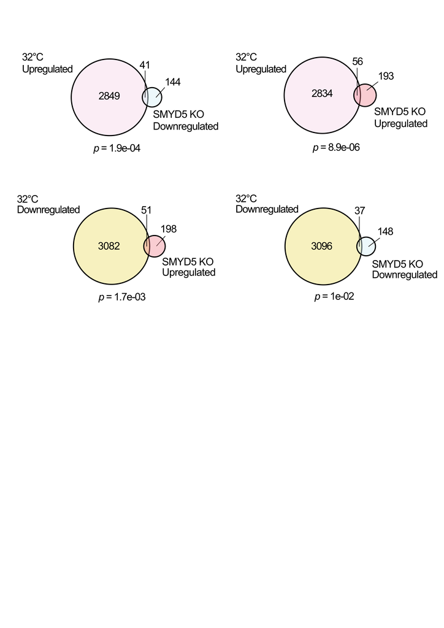

```r
knitr::include_graphics("Venn_diagrams.png")
```

## Venn diagrams of 32°C and SMYD5-bound DEGs overlaps

```r
Temp_up_SMYD5_bound_down_venn <- venn.diagram(
                  x = list(Temp_upregulated$Row.names, SMYD5_bound_down$Row.names),
                  category.names = c("32°C Upregulated" , "SMYD5 bound, KO Downregulated"),
                  filename = NULL,

                  )
pdf(file="Temp_up_SMYD5_bound_down_venn.pdf", height = 1.5, width = 1.5, pointsize = 6)
grid.draw(Temp_up_SMYD5_bound_down_venn)
dev.off()
```

```r
Temp_up_SMYD5_bound_up_venn <- venn.diagram(
                  x = list(Temp_upregulated$Row.names, SMYD5_bound_up$Row.names),
                  category.names = c("32°C Upregulated" , "SMYD5 bound, KO Upregulated"),
                  filename = NULL,

                  )
pdf(file="Temp_up_SMYD5_bound_up_venn.pdf", height = 1.5, width = 1.5, pointsize = 6)
grid.draw(Temp_up_SMYD5_bound_up_venn)
dev.off()
```

```r
Temp_down_SMYD5_bound_up_venn <- venn.diagram(
                  x = list(Temp_downregulated$Row.names, SMYD5_bound_up$Row.names),
                  category.names = c("32°C Downregulated" , "SMYD5 bound, KO Upregulated"),
                  filename = NULL,

                  )
pdf(file="Temp_down_SMYD5_bound_up_venn.pdf", height = 1.5, width = 1.5, pointsize = 6)
grid.draw(Temp_down_SMYD5_bound_up_venn)
dev.off()
```

```r
Temp_down_SMYD5_bound_down_venn <- venn.diagram(
                  x = list(Temp_downregulated$Row.names, SMYD5_bound_down$Row.names),
                  category.names = c("32°C Downregulated" , "SMYD5 bound, KO Downregulated"),
                  filename = NULL,

                  )
pdf(file="Temp_down_SMYD5_bound_down_venn.pdf", height = 1.5, width = 1.5, pointsize = 6)
grid.draw(Temp_down_SMYD5_bound_down_venn)
dev.off()
```

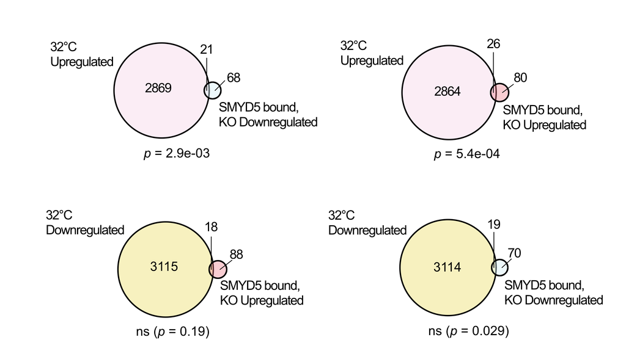

```r
knitr::include_graphics("SMYD5_bound_Venn_diagrams.png")
```

## Prepping data for Gene Set Enrichment Analysis (GSEA)

GSEA was used to identify significantly enriched gene sets within our RNAseq data. For this, we generated ranked gene lists comprising all detected genes assigned to a rank value. The rank value was calculated as -log10(q-value) × (sign of fold change). The genes were then ranked from the highest rank value to the lowest. These lists were generated in R:

```r
all.preranked.score <- all_detected_genes[,c(1,8,7,3)]
all.preranked.score.up <- filter(all.preranked.score, log2FoldChange >0)
all.preranked.score.up$score <- log10(1/all.preranked.score.up$padj)

all.preranked.score.down <- filter(all.preranked.score, log2FoldChange < 0)
all.preranked.score.down$score <- -log10(1/all.preranked.score.down$padj)

all.preranked.score.final <- rbind(all.preranked.score.up, all.preranked.score.down)
all.preranked.score.final <- all.preranked.score.final[,c(1,5)]
all.preranked.score.final <- all.preranked.score.final[order(-all.preranked.score.final$score),]
write.csv(all.preranked.score.final, "Temp_preranked_genelist.csv")

head(all.preranked.score.final)
```

```
##            Row.names     score
## 1 ENSMUSG00000045193 140.15866
## 2 ENSMUSG00000021134  61.64291
## 3 ENSMUSG00000042659  60.55915
## 4 ENSMUSG00000031167  55.51136
## 5 ENSMUSG00000020393  53.26689
## 6 ENSMUSG00000052397  52.97804
```

This file was then opened in excel, headers of all columns were deleted as well as all columns except for gene names and score. The file was saved as a tab-delimited .txt rile with the .rnk extension. This was then loaded into GSEA preranked program. We used the following settings:

```
Gene set: ftp.broadinstitute.org://pub/gsea/msigdb/mouse/gene_sets/mh.all.v2022.1.Mm.symbols.gmt
Collapse/remap to gene symbols: No_Collapse
Chip platform: ftp.broadinstitute.org://pub/gsea/msigdb/mouse/annotations/Mouse_Ensembl_Gene_ID_MSigDB.v2022.1.Mm.chip
Number of Permutations: 1000
Enrichment statistic: classic
Max size: 5000
Min size: 15
Normalisation mode: meandiv
```

## Plotting GSEA results

Now we will make bar graphs of GSEA results:

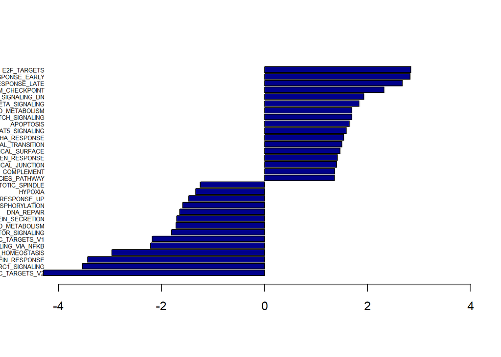

```r
Cold_pos_GSEA <- read.delim("20230112_Temp_mouse_NPCs.GseaPreranked.1673517190274/gsea_report_for_na_pos_1673517190274.tsv")
Cold_pos_GSEA.sig <- Cold_pos_GSEA[Cold_pos_GSEA$FDR.q.val < 0.25,]

Cold_neg_GSEA <- read.delim("20230112_Temp_mouse_NPCs.GseaPreranked.1673517190274/gsea_report_for_na_neg_1673517190274.tsv")
Cold_neg_GSEA.sig <- Cold_neg_GSEA[Cold_neg_GSEA$FDR.q.val < 0.25,]

Cold_GSEA.sig <- rbind(Cold_pos_GSEA.sig, Cold_neg_GSEA.sig)
Cold_GSEA.sig <- Cold_GSEA.sig[order(Cold_GSEA.sig$NES),]

Cold_GSEA_forGraph <- Cold_GSEA.sig[,c(1,6)]
Cold_GSEA_forGraph$NAME <- gsub('HALLMARK_','',Cold_GSEA_forGraph$NAME)

barplot(Cold_GSEA_forGraph$NES, horiz=TRUE, names.arg = Cold_GSEA_forGraph$NAME, las =1, xlim = c(-4,4), cex.names = 0.5, col = "darkblue")
```

```r
par(mar=c(6,12,4,4)+0.1)


pdf(file="Temp_GSEA.pdf", height = 3, width = 3, pointsize = 0.1)
par(mar=c(6,12,4,4)+0.1, lwd = 0.2)
barplot(Cold_GSEA_forGraph$NES, horiz=TRUE, names.arg = Cold_GSEA_forGraph$NAME,
        xlab = c("Normalized enrichment score"), las =1, xlim = c(-4,4), border = NA, cex.names = 0.5, col = "darkblue")
dev.off()
```

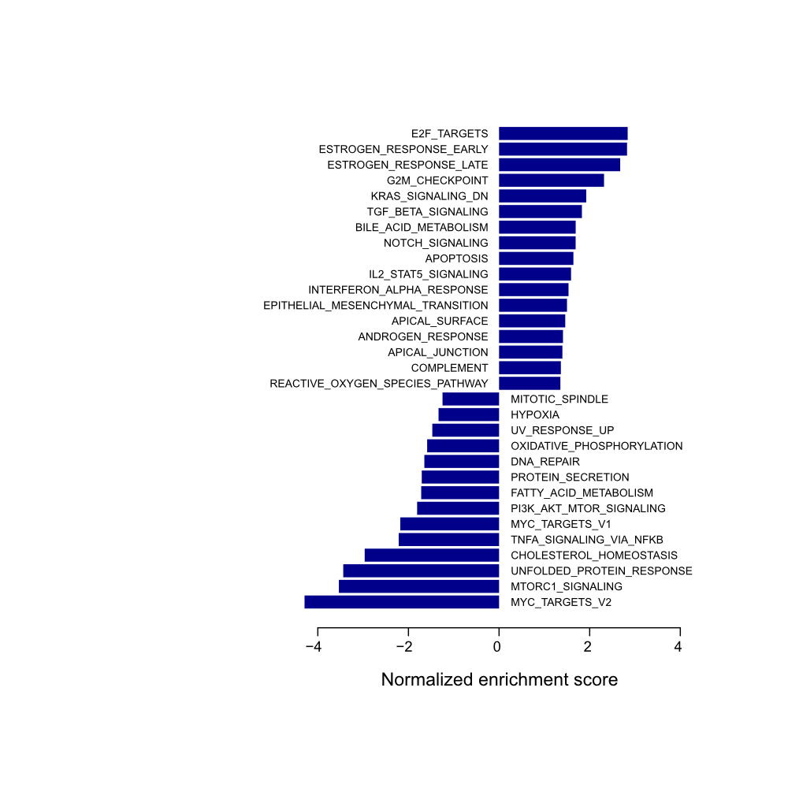

```r
knitr::include_graphics("Temp_GSEA.png")
```